# GBSG maxeff subgroup analysis: Naive, Full Bootstrap, Multiplier Resampling, and Guo & He

```r
library(forestsearch)
library(survival)
library(data.table)
library(ggplot2)
library(doFuture)
library(kableExtra)

timings <- list()

# Guo & He comparator: guohe_algorithm3() / fs_to_guohe() are package API
# (exported by forestsearch). gh_dir is kept only for the LOO cache path below.
gh_dir <- Sys.getenv("GH_DIR", unset = "../../../quarto/GuoHe")
```

```r
# PARALLELISM NOTES (see the doFuture discussion):
#   * FB  -- forestsearch_bootstrap_dofuture() uses %dofuture%; it inherits the
#            plan set here and restores the previous plan on exit. Any plan works.
#   * MR  -- the de-biased gate is vectorized matrix algebra (a single crossprod
#            over all draws), NOT a parallel loop; it needs no plan, only a
#            threaded BLAS to benefit. Do not wrap it in a future.
#   * GH  -- guohe_algorithm3()'s pair bootstrap is parallelised via its own
#            `parallel` argument. guohe_algorithm3() is package API, so any
#            plan works (workers see the installed forestsearch); forked
#            workers (plan(multicore), Linux/Mac) remain the cheapest, hence
#            the unix-only default below.
n_cores <- max(1L, floor(0.80 * parallel::detectCores(logical = FALSE)))
cat("Using", n_cores, "physical cores for parallel sections\n")
```

```
Using 102 physical cores for parallel sections
```

```r
NB         <- 1000L     # full-bootstrap resamples (production: 500-2000)
mr_draws <- 5000L     # MR multiplier draws
GH_B       <- 2000L     # Guo & He pair-bootstrap resamples
GH_r       <- 0.03      # Guo & He tuning parameter (their adaptive default region)
GH_PARALLEL <- .Platform$OS.type == "unix"   # forked GH bootstrap where available
run_loo    <- TRUE      # leave-one-out (N-fold) honest out-of-sample subgroup estimate
timings$loo <- NA_real_
# LOO fold-loop workers: 80% of physical cores (same rule as n_cores above), so
# this adapts to whichever machine renders. No nested parallelism to guard
# against: forestsearch_Kfold() pins each fold's inner forestsearch() refit to
# plan = "sequential", workers = 1, so these are the ONLY workers in play.
loo_workers <- n_cores
run_cv_kfold <- TRUE    # repeated 10-fold cross-validation (stability diagnostics)
Ksims       <- 50L      # repeated 10-fold partitions (>= 50 for production)
timings$kfold <- NA_real_
```

```r
df.analysis <- gbsg
df.analysis <- within(df.analysis, {
  id <- seq_len(nrow(df.analysis))
  time_months <- rfstime / 30.4375
  grade3 <- ifelse(grade == "3", 1, 0)
})

confounders.name <- c("age", "meno", "size", "grade3", "nodes", "pgr", "er")
outcome.name <- "time_months"
event.name   <- "status"
id.name      <- "id"
treat.name   <- "hormon"

cat("Sample size:", nrow(df.analysis), "\n")
```

```
Sample size: 686
```

```r
cat("Events:", sum(df.analysis[[event.name]]),
    sprintf("(%.1f%%)\n", 100 * mean(df.analysis[[event.name]])))
```

```
Events: 299 (43.6%)
```

## 1 Parameter provenance

Each `forestsearch()` fit carries `args_call_all`: the argument list the call actually resolved to, kept in sync by the package’s `.sync_args_call_all()` and used by `forestsearch()` for reconstruction. The table below reconciles it against `formals(forestsearch)` at render time, so the values reported are the ones the fit used rather than restated comments that can drift.

```r
.fs_fmt_val <- function(v) {
  if (is.null(v)) return("NULL")
  if (is.data.frame(v)) return(sprintf("<data.frame %d x %d>", nrow(v), ncol(v)))
  if (is.function(v)) return("<function>")
  if (is.list(v)) {
    if (length(v) == 0L) return("list()")
    nms <- names(v); if (is.null(nms)) nms <- rep("", length(v))
    inner <- vapply(seq_along(v), function(i) {
      val <- tryCatch(paste(deparse(v[[i]], width.cutoff = 200L), collapse = " "),
                      error = function(e) "<?>")
      if (nzchar(nms[i])) paste0(nms[i], " = ", val) else val
    }, character(1))
    return(paste0("list(", paste(inner, collapse = ", "), ")"))
  }
  if (length(v) > 6L) return(sprintf("<%s[%d]>", class(v)[1], length(v)))
  paste(deparse(v, width.cutoff = 200L), collapse = " ")
}

.fs_fmt_default <- function(x) {
  if (identical(x, quote(expr = ))) return("<required; no default>")
  paste(deparse(x, width.cutoff = 200L), collapse = " ")
}

# match.arg-style values resolve to their first element.  Applied to BOTH sides
# of the comparison below: a value captured unresolved (grf_selection,
# grf_select_statistic) still sits at its default and must not read as differing.
.fs_collapse_matcharg <- function(x) {
  ifelse(!is.na(x) & grepl('^c[(]"', x),
         sub('^c[(]"([^"]*)".*$', '"\\1"', x), x)
}

#' Reconcile a fit's resolved arguments against forestsearch()'s formals
fs_param_provenance <- function(fit, fn = forestsearch) {
  stopifnot(!is.null(fit), !is.null(fit$args_call_all))
  args <- fit$args_call_all
  fm   <- formals(fn)
  nm   <- setdiff(names(fm), "...")

  defaults <- vapply(fm[nm], .fs_fmt_default, character(1), USE.NAMES = FALSE)
  used <- vapply(nm, function(p) {
    if (!p %in% names(args)) return(NA_character_)
    .fs_fmt_val(args[[p]])
  }, character(1), USE.NAMES = FALSE)

  eff      <- .fs_collapse_matcharg(defaults)
  eff_used <- .fs_collapse_matcharg(used)

  out <- data.frame(
    parameter  = nm,
    default    = defaults,
    value_used = ifelse(is.na(used), "(not captured)", used),
    status     = ifelse(is.na(used), "not captured",
                 ifelse(eff_used == eff, "at default", "differs from default")),
    stringsAsFactors = FALSE
  )

  # forestsearch_main.R:1304 overrides these five under sg_focus = "maxeff" and
  # does NOT re-sync args_call_all afterwards (the package notes this itself at
  # ~2763), so what was captured is the value typed into the call, not the value
  # the engine ran with.
  if (identical(args$sg_focus, "maxeff")) {
    .ov <- c("pconsistency.threshold", "stop_threshold", "use_twostage",
             "max_subgroups_search", "minp")
    i <- out$parameter %in% .ov
    out$status[i] <- "captured BEFORE maxeff override -- not what the engine used"
  }

  out
}

#' Render a provenance table for one fit
fs_param_table <- function(fit, title) {
  pv <- fs_param_provenance(fit)
  n_diff <- sum(pv$status == "differs from default")
  sub <- sprintf(
    "%d of %d formals differ from their package default (forestsearch %s, read at render time).",
    n_diff, nrow(pv),
    tryCatch(as.character(utils::packageVersion("forestsearch")),
             error = function(e) "version unknown"))
  # Only meaningful when the maxeff override actually fired; under any other
  # sg_focus nothing is overridden and the caveat would be false.
  if (any(grepl("^captured BEFORE", pv$status))) {
    sub <- paste(sub,
      "args_call_all is not re-synced after the sg_focus = \"maxeff\" override block",
      "(forestsearch_main.R:1304; the package notes this itself at ~2763), so the",
      "rows flagged as such report the value typed into the call rather than the",
      "value the engine used -- the render's own maxeff warning lists those.")
  }
  knitr::kable(pv, caption = paste0(title, " -- ", sub))
}
```

## 2 Maxeff identification

The forest search is run under `sg_focus = "maxeff"`: the selected subgroup is the effect maximiser over the enumerated candidate family – the argmax primitive of Guo and He (2021), and the selection Guo & He’s de-biasing is built to correct. Under `maxeff` the candidate pool is not truncated, so the family the correction ranges over is the full enumerated family. The receptor cuts $\{er \le 0\}$ and $\{pgr \le 0\}$ are pre-specified as forced candidates, and $J = 10$ cuts are used for the continuous `er` and `pgr` covariates.

```
[forestsearch] Subgroup Identification Configuration
  Outcome type:   survival (Cox PH)
  Effect measure: HR (hazard ratio)
  Scale:          log (ratio)

  Screening:      HR >= 1.25  (log: 0.2231)
  Consistency:    HR >= 1.00  (log: 0.0000)
  Consistency rate threshold: 0%

  Interpretation:
    Candidates: subgroup hazard ratio >= 1.25
    Splits:     each split HR >= 1.00
```

```
  Search Alignment Diagnostic
```

```
  Outcome:    time_months (survival)
```

```
  Treatment:  hormon
```

```
  Measure:    Hazard Ratio (HR)
```

```
  ForestSearch searches for:
    Subgroups where hormon increases the event hazard
    (HR >= threshold in the candidate subgroup)
```

```
  Thresholds:
    Screening: HR >= 1.250 in the candidate subgroup
    Consistency: HR >= 1.000 in each bootstrap split
```

```
  Variable screening:
```

```
    LASSO: LASSO screening: DISABLED
```

```
    GRF:   DISABLED
```

```
  No alignment concerns detected.
```

```
Forced confounders: er <= 0, pgr <= 0
J-quantile cuts: er (J=10), pgr (J=10)
Candidate factors: 33
 [1] "er <= 0"    "pgr <= 0"   "er <= 3"    "er <= 9"    "er <= 17"
 [6] "er <= 30"   "er <= 44"   "er <= 70"   "er <= 100"  "er <= 174"
[11] "er <= 294"  "pgr <= 2"   "pgr <= 8"   "pgr <= 16"  "pgr <= 26"
[16] "pgr <= 45"  "pgr <= 77"  "pgr <= 114" "pgr <= 184" "pgr <= 337"
[21] "age <= 53"  "age <= 46"  "age <= 61"  "size <= 29" "size <= 25"
[26] "size <= 20" "size <= 35" "nodes <= 5" "nodes <= 3" "nodes <= 1"
[31] "nodes <= 7" "meno"       "grade3"
Number of possible configurations (<= maxk): maxk = 2 , # combinations = 2211
Per-arm events criteria: control >= 10, treatment >= 10
Sample size criteria: n >= 60
Subgroup search completed in 0.11 minutes

--- Filtering Summary ---
  Combinations evaluated: 2211
  Passed variance check: 2069
  Passed prevalence (>= 0 ): 2069
  Passed redundancy check: 1960
  Passed events counts (d0>= 10, d1>= 10): 1468
  Passed sample size (n>= 60 ): 1424
  Cox model fit successfully: 1424
  Passed effect threshold (effect >= 1.2500): 1424
-------------------------

Found 1424 subgroup candidate(s)
# of candidate subgroups (meeting all criteria) = 1424
# of unique initial candidates: 1340
# Restricting to top stop_Kgroups = Inf
# of candidates to evaluate: 1340

==============================================================================================================
CANDIDATE EVALUATION PREVIEW (pre-consistency) (sg_focus = "maxeff", selection_rule = "neighborhood")
==============================================================================================================
Rank  HR      N      E     K    OF  Subgroup
--------------------------------------------------------------------------------------------------------------
   1   2.537     61    34    2  *   {er <= 0} & {size <= 35}
   2   2.335     61    31    2  -   {er <= 0} & {nodes <= 7}
   3   2.285     79    43    2  *   {er <= 0} & {pgr <= 114}
   4   2.242     77    42    2  -   {er <= 0} & {pgr <= 77}
   5   2.222     75    41    2  -   {er <= 0} & {pgr <= 26}
   6   2.129     66    35    2  -   {er <= 0} & {pgr <= 8}
   7   2.054     61    35    2  -   {er <= 0} & !{size <= 20}
   8   2.035     80    43    2  *   {er <= 0} & {pgr <= 184}
   9   1.951     82    45    1  *   {er <= 0}
  10   1.918     70    38    2  -   {er <= 0} & {pgr <= 16}
... 1330 more candidates not shown (max_print = 10).
--------------------------------------------------------------------------------------------------------------
To evaluate: 1340   On frontier: 25
Legend: OF = on Pareto frontier.
==============================================================================================================

1340 subgroups passed consistency threshold
```

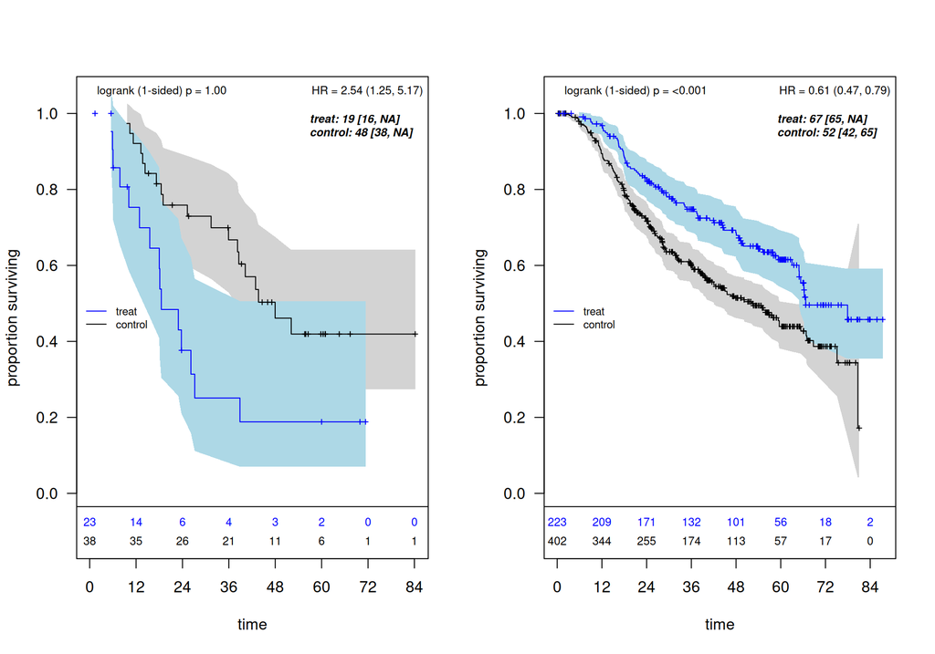

```
*** Subgroup found: {er <= 0} {size <= 35}
% consistency criteria met= 0.99
SG focus = maxeff

==============================================================================================================
CANDIDATE EVALUATION SUMMARY  (sg_focus = "maxeff", selection_rule = "neighborhood")
==============================================================================================================
Rank  HR      N      E     K    OF  S  Subgroup
--------------------------------------------------------------------------------------------------------------
   1   2.537     61    34    2  *   *  {er <= 0} & {size <= 35}
   2   2.335     61    31    2  -   -  {er <= 0} & {nodes <= 7}
   3   2.285     79    43    2  *   -  {er <= 0} & {pgr <= 114}
   4   2.242     77    42    2  -   -  {er <= 0} & {pgr <= 77}
   5   2.222     75    41    2  -   -  {er <= 0} & {pgr <= 26}
   6   2.129     66    35    2  -   -  {er <= 0} & {pgr <= 8}
   7   2.054     61    35    2  -   -  {er <= 0} & !{size <= 20}
   8   2.035     80    43    2  *   -  {er <= 0} & {pgr <= 184}
   9   1.951     82    45    1  *   -  {er <= 0}
  10   1.918     70    38    2  -   -  {er <= 0} & {pgr <= 16}
... 1330 more candidates not shown (max_print = 10).
--------------------------------------------------------------------------------------------------------------
Evaluated: 1340   Passed: 1340   On frontier: 25   Selected: m=1
Selected subgroup Pcons (consistency probability): 0.990
Legend: OF = on Pareto frontier; S = selected.
==============================================================================================================

Seconds and minutes forestsearch overall = 8.267 0.1378
Consistency algorithm used: fixed
Subgroup identified: {er <= 0} & {size <= 35}
```

```
Multiplier resampling (MR): constructing de-biased estimates from 5000 draws.
  This is post-selection inference on the completed search; it cannot change the identified subgroup.
```

```
MR harm confirmation: HR = 1.446 (point rule vs 1.00) -> consistent with harm
```

```r
t0 <- proc.time()

fs <- forestsearch(
  df.analysis,
  outcome.name          = outcome.name,
  event.name            = event.name,
  treat.name            = treat.name,
  id.name               = id.name,
  confounders.name      = confounders.name,
  is.RCT                = TRUE,
  seedit                = 8316951,
  est.scale             = "hr",
  # candidate generation: consistency search only (no LASSO/GRF/DINA screens)
  use_lasso             = FALSE,
  use_grf               = FALSE,
  use_dina              = FALSE,
  # continuous-cut construction + pre-specified receptor candidates
  conf.cont_jcuts       = list(er = 10, pgr = 10),
  collapse_cuts         = TRUE,
  conf_force            = c("er <= 0", "pgr <= 0"),
  # selection: the effect-maximiser argmax (Guo & He primitive)
  subgroup_method       = "consistency",
  sg_focus              = "maxeff",
  # subgroup constraints
  n.min                 = 60, d0.min = 10, d1.min = 10, maxk = 2,
  # Tier-2 de-biased gate (MR) computed inside the fit
  mr_inference           = TRUE,
  mr_inference_args      = list(draws = mr_draws),
  # consistency search
  consistency_method    = "resample",
  # stop_threshold: INERT here.  forestsearch_main.R:1304 sets it to NULL under
  # sg_focus = "maxeff", together with pconsistency.threshold -> 0,
  # use_twostage -> FALSE, max_subgroups_search -> Inf and minp -> 0, and warns
  # listing the overrides.  The engine never sees the value below.
  fs.splits             = 1000, stop_threshold = 0.95,
  use_twostage          = TRUE, max.minutes = 3,
  show_candidate_summary = TRUE, details = TRUE, quiet = FALSE,
  plot.sg               = TRUE,
  parallel_args = list(plan = "multisession", workers = n_cores,
                       show_message = TRUE)
)
```

```r
plan("sequential")
timings$fit <- (proc.time() - t0)[["elapsed"]]

stopifnot(!is.null(fs$sg.harm))
cat("\nSelected subgroup:", paste(fs$sg.harm, collapse = " & "),
    "  |  fit", round(timings$fit / 60, 1), "min\n")
```

```
Selected subgroup: {er <= 0} & {size <= 35}   |  fit 0.4 min
```

Resolved parameters for the maxeff fit – 20 of 85 formals differ from their package default (forestsearch 0.2.0, read at render time). args_call_all is not re-synced after the sg_focus = “maxeff” override block (forestsearch_main.R:1304; the package notes this itself at ~2763), so the rows flagged as such report the value typed into the call rather than the value the engine used – the render’s own maxeff warning lists those.

| parameter | default | value_used | status |
| --- | --- | --- | --- |
| df.analysis | <required; no default> | <data.frame 686 x 14> | differs from default |
| outcome.name | “tte” | “time_months” | differs from default |
| event.name | “event” | “status” | differs from default |
| treat.name | “treat” | “hormon” | differs from default |
| id.name | “id” | “id” | at default |
| potentialOutcome.name | NULL | NULL | at default |
| flag_harm.name | NULL | NULL | at default |
| confounders.name | NULL | <character[7]> | differs from default |
| parallel_args | list(plan = “multisession”, workers = .default_parallel_workers(), show_message = TRUE) | list(plan = “multisession”, workers = 102, show_message = TRUE) | differs from default |
| df.predict | NULL | NULL | at default |
| df.test | NULL | NULL | at default |
| is.RCT | TRUE | TRUE | at default |
| seedit | 8316951 | 8316951 | at default |
| est.scale | “hr” | “hr” | at default |
| use_lasso | TRUE | FALSE | differs from default |
| use_grf | TRUE | FALSE | differs from default |
| grf_res | NULL | NULL | at default |
| grf_cuts | NULL | NULL | at default |
| use_dina | FALSE | FALSE | at default |
| dina_res | NULL | NULL | at default |
| dina_cuts | NULL | NULL | at default |
| dina_args | list() | list(select_statistic = “dina”) | differs from default |
| dina_select_statistic | c(“dina”, “effect”) | “dina” | at default |
| subgroup_method | c(“consistency”, “dina”, “grf”) | “consistency” | at default |
| max_n_confounders | 1000 | 1000 | at default |
| grf_depth | 2 | 2 | at default |
| grf_selection | c(“tree”, “frontier”) | c(“tree”, “frontier”) | at default |
| grf_select_statistic | c(“dr”, “effect”) | c(“dr”, “effect”) | at default |
| dmin.grf | 0 | 0 | at default |
| frac.tau | 0.8 | 0.8 | at default |

[output cut: 55 more lines]

## 3 Full bootstrap (FB)

```r
t0 <- proc.time()
fs_bc <- forestsearch_bootstrap_dofuture(
  fs.est   = fs,
  nb_boots = NB,
  show_three = FALSE,
  details  = FALSE,
  parallel_args = list(plan = "multisession", workers = n_cores,
                       show_message = TRUE)
)
```

```
Bootstrap parallel config: Using user-provided settings
```

```
System max cores available: 128
```

```
Bootstrap will use: 102 workers with 'multisession' plan
```

```
Parallel plan: multisession with 102 workers.
```

```
Bootstrap iteration 1/1000
```

```
Bootstrap iteration 10/1000
```

```
Bootstrap iteration 50/1000
```

```
Bootstrap iteration 100/1000
```

```
Bootstrap iteration 250/1000
```

```
Bootstrap iteration 500/1000
```

```
Bootstrap iteration 750/1000
```

```
Bootstrap iteration 1000/1000
```

```r
plan("sequential")
timings$fb <- (proc.time() - t0)[["elapsed"]]

fb_sum <- summarize_bootstrap_results(
  sgharm = fs$sg.harm, boot_results = fs_bc,
  create_plots = FALSE, est.scale = "hr"
)
```

```
===============================================================
           BOOTSTRAP ANALYSIS SUMMARY
===============================================================

IDENTIFIED SUBGROUP:
-------------------------------------------------------------
  H: {er <= 0} & {size <= 35}

BOOTSTRAP SUCCESS METRICS:
-------------------------------------------------------------
  Total iterations:              1000
  Successful subgroup ID:        1000 (100.0%)
  Failed to find subgroup:       0 (0.0%)

TIMING ANALYSIS:
-------------------------------------------------------------
Overall:
  Total bootstrap time:          4.70 minutes (0.08 hours)
  Average per iteration:         0.00 min (0.3 sec)
```

```r
cat("FB completed in", round(timings$fb / 60, 1), "min\n")
```

```
FB completed in 4.8 min
```

## 4 Multiplier resampling (MR)

The Tier-2 de-biased gate is the MR correction, computed inside the fit above (vectorized over 5,000 draws). It is read from `fs$mr_inference`; no separate run is needed.

```r
g <- fs$mr_inference
stopifnot(!is.null(g))
timings$mr <- g$timing_seconds
cat("MR gate:", round(timings$mr, 2), "s over",
    format(mr_draws, big.mark = ","), "draws\n")
```

```
MR gate: 4.74 s over 5,000 draws
```

## 5 Guo & He (GH)

The adapter exports the maxeff candidate family as membership columns and runs Guo & He Algorithm 3 on the same selected subgroup. The membership integrity check asserts that the exported selected-subgroup column matches forestsearch’s own `sg.harm.id` exactly before the estimator runs.

```r
t0 <- proc.time()
gh <- fs_to_guohe(
  fit       = fs,
  time      = "time_months", event = "status", treatment = "hormon",
  B         = GH_B, r = GH_r, level = 0.05, seed = 8316951,
  parallel  = GH_PARALLEL, verify = TRUE
)
timings$gh <- (proc.time() - t0)[["elapsed"]]

cat("GH family size:", length(gh$export$candidates),
    " | selected:", gh$selected,
    " | GH", round(timings$gh / 60, 1), "min\n")
```

```
GH family size: 1340  | selected: sg_0001  | GH 10.6 min
```

```r
cat(sprintf("GH  naive HR %.3f  debiased HR %.3f  lower bound %.3f\n",
            gh$naive_hr, gh$debiased_hr, gh$bound_hr))
```

```
GH  naive HR 2.537  debiased HR 1.104  lower bound 0.720
```

## 6 Repeated 10-fold cross-validation (stability diagnostics)

Repeated 10-fold cross-validation partitions the data into ten folds, refits the selection on each nine-fold training set, and records which subgroup is identified – repeated over `Ksims` random partitions. It is a **stability diagnostic on the subgroup *definition***: across `Ksims` × 10 training splits, does the maxeff argmax converge on a single dominant subgroup, or does the selection wander with the particular split? This is `forestsearch_tenfold()`; because the search is data-adjacent, the recovered-subgroup distribution is the quantity of interest.

This is a pure maxeff, fixed-family analysis (no GRF, DINA, or LASSO screens), so the GRF-specific fold diagnostics are omitted; the universal ones – identified- subgroup distribution, selected-candidate consistency, per-fold numerics, and agreement with the full-data selection – are reported.

```r
cat("> **10-fold CV skipped.** Set `run_cv_kfold <- TRUE` in the",
    "configuration to enable.\n")
```

```r
t0 <- proc.time()
fs_kfold <- forestsearch_tenfold(
  fs.est  = fs,
  sims    = Ksims,
  Kfolds  = 10,
  details = FALSE,
  parallel_args = list(plan = "multisession", workers = n_cores,
                       show_message = FALSE)
)
plan("sequential")
timings$kfold <- (proc.time() - t0)[["elapsed"]]
cat("10-fold CV:", Ksims, "x 10 partitions in",
    round(timings$kfold / 60, 1), "min\n")
```

```
10-fold CV: 50 x 10 partitions in 2.8 min
```

```r
metrics_tables <- cv_metrics_tables(fs_kfold)
metrics_tables
```

**Cross-Validation Metrics**

Subgroup: Identified Subgroup

| Metric | Description | Value (%) |
| --- | --- | --- |
| Agreement |  |  |
| Sensitivity (H) | Agreement rate for subgroup H | 95.1 |
| Sensitivity (Hc) | Agreement rate for complement Hc | 96.8 |
| PPV (H) | Positive predictive value for H | 74.0 |
| PPV (Hc) | Positive predictive value for Hc | 99.5 |
| Subgroup Finding |  |  |
| Any Found | Any subgroup identified | 100.0 |
| Exact Match | Exact match on all factors | 0.0 |
| At Least 1 | At least one factor matches | 100.0 |
| Cov1 Any | First covariate found (any cut) | 100.0 |
| Cov2 Any | Second covariate found (any cut) | 0.0 |
| Cov1 & Cov2 | Both covariates found | 0.0 |
| Cov1 Exact | First covariate exact match | 100.0 |
| Cov2 Exact | Second covariate exact match | 0.0 |

Based on 50 simulation(s) with 10-fold CV. Values are medians shown as percentages.

### 6.1 Diagnostic tabulations

`summarize_cv_results()` consolidates the per-fold record into diagnostic tables. For this maxeff fixed-family analysis the meaningful (non-GRF) diagnostics are: the distribution of identified subgroups across resamples, the consistency of the selected candidates, the per-fold numeric summary, and agreement with the full-data selection.

```r
cv_diag <- summarize_cv_results(
  cv_output    = fs_kfold,
  original_sg  = fs$sg.harm,
  top_n        = 10L,
  create_plots = TRUE
)
```

**Which subgroups emerged across resamples?** The identification summary shows the distribution of selected subgroups across all 50 × 10 sim × fold pairs. A single dominant subgroup with high share indicates the maxeff argmax converges on a stable selection; a long tail indicates the selection is sensitive to the training split.

```r
cv_diag$identification_summary
```

**Identified subgroups across sim x fold pairs**

50 simulations x 10 folds = 500 total pairs

| Rank | Identified subgroup | n folds | % folds |
| --- | --- | --- | --- |
| 1 | {er <= 0} & {pgr <= 113} | 69 | 13.80 |
| 2 | {er <= 0} & {pgr <= 116} | 66 | 13.20 |
| 3 | {er <= 0} & {pgr <= 114} | 59 | 11.80 |
| 4 | {er <= 0} & {pgr <= 115} | 42 | 8.40 |
| 5 | {er <= 0} & {pgr <= 120} | 39 | 7.80 |
| 6 | {er <= 0} & {pgr <= 111} | 31 | 6.20 |
| 7 | {er <= 0} & {pgr <= 112} | 18 | 3.60 |
| 8 | {er <= 0} & {pgr <= 180} | 17 | 3.40 |
| 9 | {er <= 0} & {pgr <= 110} | 14 | 2.80 |
| 10 | {er <= 0} & {pgr <= 119} | 14 | 2.80 |
| 11 | (38 others) | 131 | 26.20 |

**How confidently were the successful identifications made?** Among folds that identified a subgroup, the `pconsistency_distribution` shows where the selected candidate’s consistency probability (`Pcons`) landed. (Under maxeff no consistency threshold is applied at selection, so this is descriptive of the selected argmax, not a gate.)

```r
cv_diag$pconsistency_distribution
```

**Pcons distribution among identifying folds**

Out of 500 sim x fold pairs

| Pcons range | n folds | % of identifying folds |
| --- | --- | --- |
| <0.5 | 0 | 0.00 |
| 0.5-0.7 | 0 | 0.00 |
| 0.7-0.8 | 0 | 0.00 |
| 0.8-0.85 | 0 | 0.00 |
| 0.85-0.95 | 31 | 6.20 |
| >=0.95 | 469 | 93.80 |
| Median (identifying): 0.980 | – | – |
| IQR (identifying): 0.970 - 0.990 | – | – |
| Identifying folds total | 500 | 100.00 |

Restricted to folds that identified a subgroup. A concentration near the pconsistency.threshold (typically 0.90) suggests many identifications are marginal; concentration above 0.95 suggests robust identifications. Values for rejected candidates are not surfaced -- only the selected candidate's Pcons is captured.

**How do the numeric fold-level diagnostics summarize?** The `fold_numeric_summary` tabulates median / IQR / range for each numeric fold-level column: fold size (`n_test`), training-fold HR of the selected subgroup (`training_fs_hr`, in-sample and optimistically biased – for diagnostic comparison only), and candidate count (`n_candidates_evaluated`).

```r
cv_diag$fold_numeric_summary
```

**Fold-level numeric diagnostics**

Across 500 sim x fold pairs; per-metric denominator shown in Context

| Metric | n | Median | Q1 | Q3 | Min | Max | n NA | Context |
| --- | --- | --- | --- | --- | --- | --- | --- | --- |
| Test-fold size (n_test) | 500 | 69.000 | 68.000 | 69.000 | 68.000 | 69.000 | 0 | All sim x fold pairs |
| Pcons (identifying folds) | 500 | 0.980 | 0.970 | 0.990 | 0.880 | 1.000 | 0 | Folds that identified a subgroup |
| Training-fold subgroup effect (identifying folds) | 500 | 2.272 | 2.117 | 2.462 | 1.698 | 3.879 | 0 | Natural scale; in-sample; optimistically biased |
| Candidates evaluated per fold | 500 | 1,223.000 | 1,202.000 | 1,271.250 | 1,105.000 | 1,396.000 | 0 | Folds where consistency stage ran |

Training-fold subgroup effects are in-sample estimates on the effect measure's natural scale (HR for survival; OR, RR, IRR, RD, IRD, or MD for GLM). They are optimistically biased and shown here for diagnostic comparison across folds only; do not use for inference.

**Agreement with the full-data analysis.** How often does a training fold reproduce the original full-data subgroup exactly, or share a factor with it?

```r
cv_diag$original_agreement
```

**Agreement with original full-data analysis**

Fraction of sim x fold pairs matching the original result

|  | Value |
| --- | --- |
| Total sim x fold pairs | 500 |
| Original subgroup definition | {er <= 0} & {size <= 35} |
| Exact subgroup match | 0 (0.0%) |
| Partial match (>=1 shared factor) | 484 (96.8%) |

**Identified-subgroup distribution (plot).** The bar chart of the top identified subgroups across the 50 × 10 partitions visualizes the stability of the maxeff selection: a dominant bar is a stable definition, a flat spread is an unstable one.

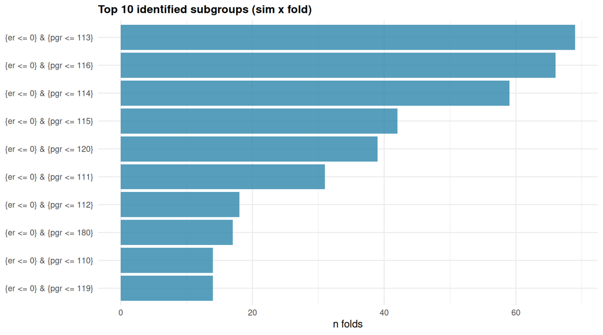

Distribution of identified subgroups across repeated 10-fold training splits.

```r
if (!is.null(cv_diag$plots) && !is.null(cv_diag$plots$identification)) {
  cv_diag$plots$identification
}
```

## 7 Leave-one-out (honest out-of-sample estimate)

Leave-one-out re-runs the entire selection on each hold-out of one subject and predicts the held-out subject’s subgroup membership from its covariates. It is an out-of-sample **stability check on the subgroup *definition***, not a de-biasing correction of the *effect*: it asks whether the same subgroup is recovered when no subject informs its own label. This is `forestsearch_Kfold()` at N-fold (`Kfolds = nrow(df)`), applied to the selected maxeff fit.

Unlike the coarse frozen-family companion analysis – where the median-cut family is small, so the argmax has few candidates to choose among and the recovered definition is mechanically stable – the maxeff family here is the full, finer-grained candidate set (quantile cuts on the continuous covariates). The argmax therefore has genuine room to land on different definitions across folds, so this is the **discriminating** leave-one-out comparison: whether the out-of-sample estimate tracks Naive (definition perfectly stable) or one of the de-biasing corrections (definition varies fold to fold, so out-of-sample membership differs from in-sample) is informative rather than predetermined. The recovered-definition distribution and the out-of-sample hazard ratio are reported below; read them against the agreement metrics.

Note this is the heaviest step: N-fold means one full forest search per subject. It is the long pole; on the analysis box, not the sandbox.

The fold loop is distributed across 102 workers. `parallel_args` controls **fold-level** parallelism only – each fold’s inner `forestsearch()` refit is pinned to `plan = "sequential"`, so there is no nested oversubscription – and the fold loop draws parallel-safe L’Ecuyer streams (`.options.future = list(seed = TRUE)`). In the frozen-family companion analysis the parallel fold loop was verified against a sequential run of the same analysis: **identical** per-subject predictions and an identical out-of-sample HR, at 5.2x the speed on 11 workers.

```r
cat("Leave-one-out skipped (run_loo = FALSE).",
    "Set run_loo <- TRUE in parallel-setup to run it.\n")
```

```r
# Leave-one-out (N-fold) is the long pole -- one full forest search per subject.
# If a precomputed cv_out is available (LOO_CACHE env var, else the default path
# in gh_dir) load it; otherwise run the N-fold search and cache it for
# re-renders. The fold loop runs in parallel on loo_workers workers; each fold's
# inner search is pinned sequential by forestsearch_Kfold().
loo_cache <- Sys.getenv("LOO_CACHE",
                        unset = file.path(gh_dir, "cv_out_maxeff.rds"))
if (file.exists(loo_cache)) {
  cv_out <- readRDS(loo_cache)
  timings$loo <- NA_real_
  cat("LOO loaded from cache:", loo_cache, "\n")
} else {
  t0 <- proc.time()
  fs_OOB <- forestsearch_Kfold(
    fs.est  = fs,
    details = FALSE,
    Kfolds  = nrow(df.analysis),   # N-fold = leave-one-out
    parallel_args = list(plan = "multisession", workers = loo_workers,
                         show_message = TRUE)
  )
  plan("sequential")
  timings$loo <- (proc.time() - t0)[["elapsed"]]
  cv_out <- forestsearch_KfoldOut(res = fs_OOB, details = FALSE, outall = TRUE)
  saveRDS(cv_out, loo_cache)
}
```

```
LOO loaded from cache: ../../../quarto/GuoHe/cv_out_maxeff.rds
```

```r
# Out-of-sample harm-subgroup HR, read BY IDENTITY (the harm row of the K-fold
# table, matched on its subgroup label sg0.name = "Not recommend"), never
# positionally -- the table layout depends on n_sgfound. Two structural cases:
#   (i)  stable subgroup: SG_tab_Kfold is a matrix whose harm row carries the
#        sg0.name label -> its out-of-sample HR (identical to tab_all's KfA_0);
#   (ii) ITT fallback: no stable subgroup survives out-of-sample (n_sgfound == 1)
#        and SG_tab_Kfold collapses to the 1-D ITT vector -> no harm row ->
#        report the fallback explicitly. In the finer maxeff family this branch
#        may genuinely trigger if the argmax definition varies across folds.
.loo_harm_row <- function(cv_out, harm_label = "Not recommend") {
  sgk <- cv_out$SG_tab_Kfold
  if (is.matrix(sgk) && "Subgroup" %in% colnames(sgk)) {
    j <- which(sgk[, "Subgroup"] == harm_label)
    if (length(j) == 1L)
      return(list(case = "stable",
                  hr   = as.character(sgk[j, "HR (95% CI)"]),
                  n    = as.character(sgk[j, "n"])))
  }
  list(case = "itt_fallback",
       hr   = "\u2014 (no stable subgroup out-of-sample; ITT)",
       n    = NA_character_)
}
loo <- .loo_harm_row(cv_out)

# Definition stability: fold recovery and agreement with the full-data subgroup.
metr <- cv_out$sens_metrics_original
cat(sprintf(
  "LOO [%s]: out-of-sample harm HR %s (n = %s)\n  agreement: sens_H = %.2f, ppv_H = %.2f (exact-match = %.2f)\n",
  loo$case, loo$hr, loo$n, metr[["sens_H"]], metr[["ppv_H"]],
  cv_out$find_metrics[["Exact"]]))
```

```
LOO [stable]: out-of-sample harm HR 1.80 (0.82, 3.97) (n = 51 (7.4%))
  agreement: sens_H = 0.82, ppv_H = 0.98 (exact-match = 0.91)
```

```r
# Full CV tables (ITT / full-analysis / K-fold, plus agreement metrics).
tables <- cv_summary_tables(cv_out)
tables$combined_table
```

**Cross-Validation Summary**

ITT and Subgroup Estimates: Full Analysis (FA) vs K-fold (Kf)

| Analysis | Subgroup | n | n1 | m1 | m0 | RMST | Hazard ratio |
| --- | --- | --- | --- | --- | --- | --- | --- |
| Overall | ITT | 686 (100.0%) | 246 (35.9%) | 66.3 | 50.2 | 7.8 | 0.69 (0.54, 0.89) |
| FA_0 | Not recommend | 61 (8.9%) | 23 (37.7%) | 18.5 | 48 | -19 | 2.54 (1.25, 5.17) |
| KfA_0 | Not recommend | 51 (7.4%) | 16 (31.4%) | 23.7 | 42.9 | -12 | 1.80 (0.82, 3.97) |
| FA_1 | Recommend | 625 (91.1%) | 223 (35.7%) | 66.7 | 52.2 | 9.6 | 0.61 (0.47, 0.79) |
| KfA_1 | Recommend | 635 (92.6%) | 230 (36.2%) | 66.7 | 52.2 | 8.5 | 0.65 (0.50, 0.84) |

FA = Full Analysis (original data), Kf = K-fold CV estimate

```r
tables$metrics_table
```

**Cross-Validation Metrics**

Agreement and subgroup finding rates (%)

| Metric | Value (%) |
| --- | --- |
| Agreement |  |
| Sensitivity (H) | 81.967 |
| Sensitivity (Hc) | 99.840 |
| PPV (H) | 98.039 |
| PPV (Hc) | 98.268 |
| Finding |  |
| Any Found | 100.000 |
| Exact Match | 90.962 |
| At Least 1 | 100.000 |
| Cov1 Any | 100.000 |
| Cov2 Any | 90.962 |
| Cov1 & Cov2 | 90.962 |
| Cov1 Exact | 100.000 |
| Cov2 Exact | 90.962 |

## 8 Comparison: four corrections on the selected subgroup

Subgroup hazard ratios for the GBSG selected (maxeff) subgroup. Parenthetical values are 95% intervals; Guo & He reports a one-sided lower bound. Leave-one-out is NOT a de-biasing correction: it is an out-of-sample stability check on the subgroup definition. Whether it tracks Naive or a correction is informative in this finer maxeff family (see the leave-one-out section).

| Method | Estimate |
| --- | --- |
| Naive | 2.54 |
| Full bootstrap | 1.95 (0.87, 4.41) |
| Multiplier resampling | 1.45 (0.62, 3.36) |
| Guo & He (2021) | 1.10 (LB 0.72) |
| Leave-one-out (out-of-sample) | 1.80 (0.82, 3.97) |

**NoteReading the table**

Naive is the uncorrected subgroup hazard ratio. Full bootstrap and Multiplier resampling both target the conditional estimand and report two-sided intervals; they differ in that FB re-runs the entire selection on each resample (so its cost scales with the resample count) while MR holds the fitted family fixed and is vectorized (so its cost does not). Guo & He corrects the winner’s-curse optimism of the argmax selection and reports a de-biased point estimate with a one-sided lower confidence bound – the object their Theorems 4/5 and simulations certify.

Leave-one-out is **not a de-biasing correction** and should not be read as one. It is an out-of-sample **stability check on the subgroup *definition***: it asks whether the same subgroup is recovered when no subject informs its own label. Its value here depends on the fold-recovery behaviour, which the agreement metrics report. If every fold recovers the *identical* definition, out-of-sample membership equals in-sample membership and the leave-one-out HR is mechanically the naive one – so `LOO = Naive` would indicate a perfectly stable definition, not a failure to correct. If the argmax instead lands on *different* definitions across folds (which the finer maxeff family makes possible, unlike the coarse frozen-family companion), out-of-sample membership departs from in-sample and the leave-one-out HR moves away from Naive – and *where* it moves is the informative signal. Read the leave-one-out row together with the agreement metrics (`sens_H`, `ppv_H`, exact-match): they say whether the definition is stable, and the HR says what the honest out-of-sample effect is for that (possibly varying) membership. Leave-one-out validates the *definition*; the de-biasing corrections address the *effect* optimism – distinct questions, so agreement or disagreement between the leave-one-out row and the corrections is not a contradiction.

| Step | Seconds | Minutes |
| --- | --- | --- |
| Fit + MR gate | 22.855 | 0.38 |
| Full bootstrap | 285.828 | 4.76 |
| MR gate (within fit) | 4.741 | 0.08 |
| Guo & He bootstrap | 637.655 | 10.63 |
| 10-fold CV | 170.468 | 2.84 |
| Leave-one-out (N-fold, 102 workers) | NA | NA |